# COMPSCIX 415.2 Homework 5/Midterm

Elizabeth Eldridge

March 3, 2019

[Click here for hyperlink to my repository!](https://github.com/lizgit19/compscix-415-2-assignments/tree/master/Lab_5)

## Question 1

1. Can you name which package is associated with each task below?

Plotting - ggplot2  
Data munging/wrangling - dplyr  
Reshaping (speading and gathering) data - dplyr  
Importing/exporting data - readr

## Question 2

2. Now can you name two functions that you’ve used from each package that you listed above for these tasks?

Plotting - geom_point, geom_bar  
Data munging/wrangling - select(), filter()  
Reshaping data - gather(), spread()  
Importing/exporting data - read_csv(), write_csv()

## R Basics (1.5 points)

1. Fix this code with the fewest number of changes possible so it works:

```r
#My_data.name___is.too00ooLong! <- c( 1 , 2 , 3 )
My_data.name___is.too00ooLong <- c( 1 , 2 , 3 )
```

2. Fix this code so it works:

```r
#my_string <- C('has', 'an', 'error', 'in', 'it)
my_string <- c('has', 'an', 'error', 'in', 'it')
```

3. Look at the code below and comment on what happened to the values in the vector.
- R coerced the entire vector to character even though some values are numeric because we cannot have a vector with values of multiple different types. We can check this using various commands to test the type of vector.

```r
my_vector <- c(1, 2, '3', '4', 5)
my_vector
```

```
## [1] "1" "2" "3" "4" "5"
```

```r
typeof(my_vector)
```

```
## [1] "character"
```

```r
is.numeric(my_vector)
```

```
## [1] FALSE
```

```r
is.character(my_vector)
```

```
## [1] TRUE
```

## Data import/export (3 points)

1. Download the rail_trail.txt file from Canvas (in the Midterm Exam section) and successfully import it into R. Prove that it was imported successfully by including your import code and taking a glimpse of the result.

```r
railtrail_dsn <- read_delim('I:/rail_trail.txt', delim="|")
glimpse(railtrail_dsn)
```

```
## Observations: 90
## Variables: 10
## $ hightemp   <int> 83, 73, 74, 95, 44, 69, 66, 66, 80, 79, 78, 65, 41,...
## $ lowtemp    <int> 50, 49, 52, 61, 52, 54, 39, 38, 55, 45, 55, 48, 49,...
## $ avgtemp    <dbl> 66.5, 61.0, 63.0, 78.0, 48.0, 61.5, 52.5, 52.0, 67....
## $ spring     <int> 0, 0, 1, 0, 1, 1, 1, 1, 0, 0, 0, 1, 1, 0, 0, 1, 0, ...
## $ summer     <int> 1, 1, 0, 1, 0, 0, 0, 0, 1, 1, 1, 0, 0, 0, 0, 0, 1, ...
## $ fall       <int> 0, 0, 0, 0, 0, 0, 0, 0, 0, 0, 0, 0, 0, 1, 1, 0, 0, ...
## $ cloudcover <dbl> 7.6, 6.3, 7.5, 2.6, 10.0, 6.6, 2.4, 0.0, 3.8, 4.1, ...
## $ precip     <dbl> 0.00, 0.29, 0.32, 0.00, 0.14, 0.02, 0.00, 0.00, 0.0...
## $ volume     <int> 501, 419, 397, 385, 200, 375, 417, 629, 533, 547, 4...
## $ weekday    <int> 1, 1, 1, 0, 1, 1, 1, 0, 0, 1, 1, 1, 1, 1, 1, 1, 0, ...
```

2. Export the file into a comma-separated file and name it “rail_trail.csv”. Make sure you define the path correctly so that you know where it gets saved. Then reload the file. Include your export and import code and take another glimpse.

```r
write_csv(railtrail_dsn, 'I:/rail_trail.csv')
look_again <- read_csv('I:/rail_trail.csv')
glimpse(look_again)
```

```
## Observations: 90
## Variables: 10
## $ hightemp   <int> 83, 73, 74, 95, 44, 69, 66, 66, 80, 79, 78, 65, 41,...
## $ lowtemp    <int> 50, 49, 52, 61, 52, 54, 39, 38, 55, 45, 55, 48, 49,...
## $ avgtemp    <dbl> 66.5, 61.0, 63.0, 78.0, 48.0, 61.5, 52.5, 52.0, 67....
## $ spring     <int> 0, 0, 1, 0, 1, 1, 1, 1, 0, 0, 0, 1, 1, 0, 0, 1, 0, ...
## $ summer     <int> 1, 1, 0, 1, 0, 0, 0, 0, 1, 1, 1, 0, 0, 0, 0, 0, 1, ...
## $ fall       <int> 0, 0, 0, 0, 0, 0, 0, 0, 0, 0, 0, 0, 0, 1, 1, 0, 0, ...
## $ cloudcover <dbl> 7.6, 6.3, 7.5, 2.6, 10.0, 6.6, 2.4, 0.0, 3.8, 4.1, ...
## $ precip     <dbl> 0.00, 0.29, 0.32, 0.00, 0.14, 0.02, 0.00, 0.00, 0.0...
## $ volume     <int> 501, 419, 397, 385, 200, 375, 417, 629, 533, 547, 4...
## $ weekday    <int> 1, 1, 1, 0, 1, 1, 1, 0, 0, 1, 1, 1, 1, 1, 1, 1, 0, ...
```

## Visualization (6 points)

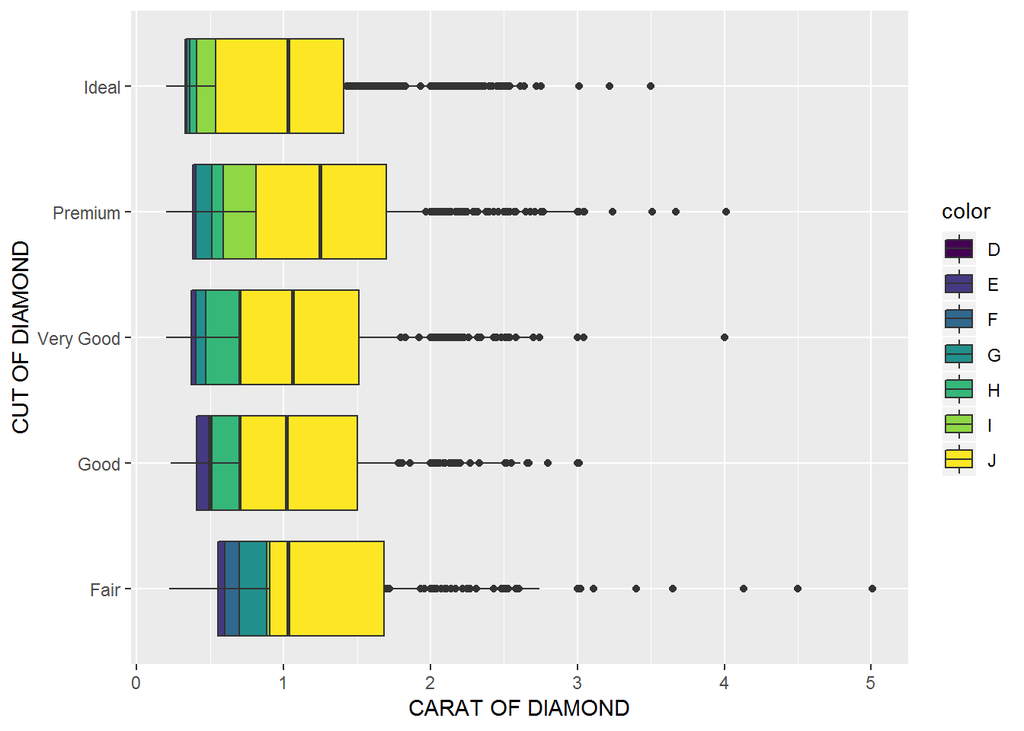

```r
ggplot(data = diamonds) +
    geom_boxplot(mapping = aes(x = cut, y=carat, fill = color), position="identity") +
    coord_flip() +
    xlab("CUT OF DIAMOND") +
    ylab("CARAT OF DIAMOND")
```

3. The previous graphic is not very useful. We can make it much more useful by changing one thing about it. Make the change and plot it again.
- The colors in the Legend are all overlaid using the position=“identity” method, but if we change this to position=“dodge” then we can actually see the differences by color.

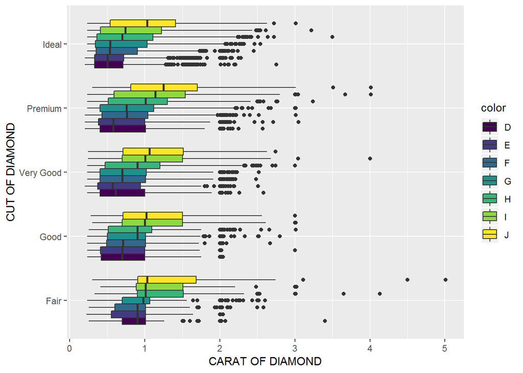

```r
ggplot(data = diamonds) +
    geom_boxplot(mapping = aes(x = cut, y=carat, fill = color), position="dodge") +
    coord_flip() +
    xlab("CUT OF DIAMOND") +
    ylab("CARAT OF DIAMOND")
```

## Data munging and wrangling (6 points)

1. Is this data “tidy”? If yes, leave it alone and go to the next problem. If no, make it tidy.
- This dataset is tidy because each variable is a column and each observation is a row, however it could be made more useful to work with by re-shaping the data.

```r
#View(table2)
```

2. Create a new column in the diamonds data set called price_per_carat that shows the price of each diamond per carat (hint: divide). Only show me the code, not the output.

```r
#new_dsn <- mutate(diamonds, price_per_carat=carat/price)
#head(new_dsn)
```

3. For each cut of a diamond in the diamonds data set, how many diamonds, and what proportion, have a price > 10000 and a carat < 1.5? There are several ways to get an answer, but your solution must use the data weangling verbs from the tidyverse in order to get credit.

Do the results make sense? Why?

- It makes sense that this is a low proportion because generally we would think that a higher-priced diamond does not have a lower number of carats.

Do we need to be wary of any of these numbers? Why?

- The fact that these are grouped by Cut likely impacts the relationship between price and carat so we should look at this overall before making assumptions directly from this grouping.

```r
#head(diamonds)

by_cut <- group_by(diamonds, cut)
  summarize(by_cut,
            count=n(),
            n_hiprice = sum(price > 10000),
            n_lowcarat = sum(carat < 1.5),
            hiprice_lowcarat = sum((price > 10000) & (carat < 1.5)),
            prop_diam = (hiprice_lowcarat/count)
            )
```

```
## # A tibble: 5 x 6
##   cut       count n_hiprice n_lowcarat hiprice_lowcarat prop_diam
##   <ord>     <int>     <int>      <int>            <int>     <dbl>
## 1 Fair       1610       147       1285                4   0.00248
## 2 Good       4906       374       4265               17   0.00347
## 3 Very Good 12082      1124      10708              155   0.0128
## 4 Premium   13791      1807      11552              173   0.0125
## 5 Ideal     21551      1770      19895              485   0.0225
```

## EDA (6 points)

Take a look at the txhousing data set that is included with the ggplot2 package and answer these questions:

```r
#head(txhousing, 50)

#1
unique(txhousing$year)
```

```
##  [1] 2000 2001 2002 2003 2004 2005 2006 2007 2008 2009 2010 2011 2012 2013
## [15] 2014 2015
```

```r
#2
summarize(txhousing,
    dist_year = n_distinct(year),
    dist_city = n_distinct(city)
)
```

```
## # A tibble: 1 x 2
##   dist_year dist_city
##       <int>     <int>
## 1        16        46
```

```r
#3
(arrange(txhousing, desc(sales)))
```

```
## # A tibble: 8,602 x 9
##    city     year month sales     volume median listings inventory  date
##    <chr>   <int> <int> <dbl>      <dbl>  <dbl>    <dbl>     <dbl> <dbl>
##  1 Houston  2015     7  8945 2568156780 217600    23875       3.4 2016.
##  2 Houston  2006     6  8628 1795898108 155200    36281       5.6 2006.
##  3 Houston  2013     7  8468 2168720825 187800    21497       3.3 2014.
##  4 Houston  2015     6  8449 2490238594 222400    22311       3.2 2015.
##  5 Houston  2013     5  8439 2121508529 186100    20526       3.3 2013.
##  6 Houston  2014     6  8391 2342443127 211200    19725       2.9 2014.
##  7 Houston  2014     7  8391 2278932511 199700    20214       3   2014.
##  8 Houston  2014     8  8167 2195184825 202400    20007       2.9 2015.
##  9 Houston  2013     8  8155 2083377894 186700    21366       3.3 2014.
## 10 Houston  2006     5  8040 1602621368 151200    35398       5.5 2006.
## # ... with 8,592 more rows
```

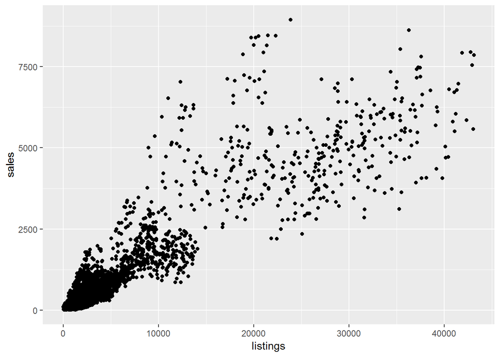

```r
#4
ggplot(data = txhousing) +
    geom_point(mapping = aes(x = listings, y = sales))
```

```r
#5
group_by(txhousing, city) %>%
  summarize(total = n(),
            missing2 = sum(is.na(sales)),
            prop_miss_sales =(missing2/total))
```

```
## # A tibble: 46 x 4
##    city                  total missing2 prop_miss_sales
##    <chr>                 <int>    <int>           <dbl>
##  1 Abilene                 187        0          0
##  2 Amarillo                187        0          0
##  3 Arlington               187        0          0
##  4 Austin                  187        0          0
##  5 Bay Area                187        0          0
##  6 Beaumont                187        0          0
##  7 Brazoria County         187       14          0.0749
##  8 Brownsville             187        2          0.0107
##  9 Bryan-College Station   187        0          0
## 10 Collin County           187        0          0
## # ... with 36 more rows
```

```r
#6
limited_dsn <- filter(txhousing, sales > 500) #1,883 rows

group_by(limited_dsn, city) %>%
  summarize(mean_median = mean(median),
            med_median = median(median),
            IQR_med = IQR(median)
            )
```

```
## # A tibble: 14 x 4
##    city              mean_median med_median IQR_med
##    <chr>                   <dbl>      <dbl>   <dbl>
##  1 Arlington             133451.     129300   10800
##  2 Austin                181998.     179400   39500
##  3 Bay Area              156586.     156250   27050
##  4 Collin County         201890.     196000   36300
##  5 Corpus Christi        130720      129300    3400
##  6 Dallas                160783.     154500   18050
##  7 Denton County         168869.     163200   18900
##  8 El Paso               123958.     131200   35675
##  9 Fort Bend             185634.     177500   47825
## 10 Fort Worth            114231.     114600   17725
## 11 Houston               149780.     148400   26950
## 12 Montgomery County     185814.     178750   42475
## 13 NE Tarrant County     165682.     160800   22700
## 14 San Antonio           138470.     143300   42000
```

1. During what time period is this data from?
- The data in this dataset ranges from Year 2000 to Year 2015
2. How many cities are represented?
- There are 46 distinct cities represented.
3. Which city, month and year had the highest number of sales?
- The highest number of sales were seen in Houston in July of 2015.
4. What kind of relationship do you think exists between the number of listings and the number of sales? Check your assumption and show your work.
- Based on the plot, we can see a positive assoication between number of listings and number of sales in the the more listings there are, the more sales there are.
5. What proportion of sales is missing for each city?
- See prop_miss_sales variable above for proportion of missing sales by city.
6. Looking at only the cities and months with greater than 500 sales:

Are the distributions of the median sales price (column name median), when grouped by city, different? The same? Show your work.

- Distributions are different by city as seen above.

Any cities that stand out that you’d want to investigate further?

Why might we want to filter out all cities and months with sales less than 500?

- We would want to filter these out because these are outliers that would skew our analyses when looking at overall analyses of the data.